# Topic: Automobile price prediction

### Predicting the price of used cars is one of the significant and interesting areas of analysis. As an increased demand in the second-hand car market, the business for both buyers and sellers has increased. this project we try to find the important features that influence the price of cars and make a model as accurate as possible to predict the price of any car.

## importing Libraries

```python
import numpy as np
import pandas as pd
import seaborn as sns
%matplotlib inline
import matplotlib.pyplot as plt
from scipy import stats
from sklearn . model_selection import train_test_split
from sklearn.preprocessing import LabelEncoder
from sklearn.linear_model import LinearRegression
from sklearn.feature_selection import SelectKBest
from sklearn.feature_selection import chi2
from sklearn.neighbors import KNeighborsRegressor
from sklearn.metrics import mean_squared_error, r2_score
from sklearn.ensemble import RandomForestRegressor
from sklearn.metrics import r2_score
```

## READING DATASET

```python
automobile=pd.read_csv("C:\\Users\\HP\\Downloads\\Auto_imports.csv")
```

## EDA (EXPLORATORY DATA ANALYSIS)

```python
automobile.shape
```

```
(201, 26)
```

### Dataset contain 201 rows and 26 columns

### See first five rows

```python
automobile.head()
```

|  | symboling | normalized-losses | make | fuel-type | aspiration | num-of-doors | body-style | drive-wheels | engine-location | wheel-base | ... | engine-size | fuel-system | bore | stroke | compression-ratio | horsepower | peak-rpm | city-mpg | highway-mpg | price |
| --- | --- | --- | --- | --- | --- | --- | --- | --- | --- | --- | --- | --- | --- | --- | --- | --- | --- | --- | --- | --- | --- |
| 0 | 3 | ? | alfa-romero | gas | std | two | convertible | rwd | front | 88.6 | ... | 130 | mpfi | 3.47 | 2.68 | 9.0 | 111 | 5000 | 21 | 27 | 13495 |
| 1 | 3 | ? | alfa-romero | gas | std | two | convertible | rwd | front | 88.6 | ... | 130 | mpfi | 3.47 | 2.68 | 9.0 | 111 | 5000 | 21 | 27 | 16500 |
| 2 | 1 | ? | alfa-romero | gas | std | two | hatchback | rwd | front | 94.5 | ... | 152 | mpfi | 2.68 | 3.47 | 9.0 | 154 | 5000 | 19 | 26 | 16500 |
| 3 | 2 | 164 | audi | gas | std | four | sedan | fwd | front | 99.8 | ... | 109 | mpfi | 3.19 | 3.4 | 10.0 | 102 | 5500 | 24 | 30 | 13950 |
| 4 | 2 | 164 | audi | gas | std | four | sedan | 4wd | front | 99.4 | ... | 136 | mpfi | 3.19 | 3.4 | 8.0 | 115 | 5500 | 18 | 22 | 17450 |

5 rows × 26 columns

## Data Attributes , Range , Type

## 1. symboling: -3, -2, -1, 0, 1, 2, 3. int

## 2. normalized-losses: continuous from 65 to 256. object

## 3. make: alfa-romero, audi, bmw, chevrolet, dodge, honda, object

## isuzu, jaguar, mazda, mercedes-benz, mercury,

## mitsubishi, nissan, peugot, plymouth, porsche,

## renault, saab, subaru, toyota, volkswagen, volvo

## 4. fuel-type: diesel, gas. object

## 5. aspiration: std, turbo. object

## 6. num-of-doors: four, two. object

## 7. body-style: hardtop, wagon, sedan, hatchback, convertible. object

## 8. drive-wheels: 4wd, fwd, rwd. object

## 9. engine-location: front, rear. object

## 10. wheel-base: continuous from 86.6 120.9. float

## 11. length: continuous from 141.1 to 208.1. float

## 12. width: continuous from 60.3 to 72.3. float

## 13. height: continuous from 47.8 to 59.8. float

## 14. curb-weight: continuous from 1488 to 4066. float

## 15. engine-type: dohc, dohcv, l, ohc, ohcf, ohcv, rotor. object

## 16. num-of-cylinders: eight, five, four, six, three, twelve, two. object

## 17. engine-size: continuous from 61 to 326. float

## 18. fuel-system: 1bbl, 2bbl, 4bbl, idi, mfi, mpfi, spdi, spfi. object

## 19. bore: continuous from 2.54 to 3.94. object

## 20. stroke: continuous from 2.07 to 4.17. object

## 21. compression-ratio: continuous from 7 to 23. float

## 22. horsepower: continuous from 48 to 288. object

## 23. peak-rpm: continuous from 4150 to 6600. object

## 24. city-mpg: continuous from 13 to 49. int

## 25. highway-mpg: continuous from 16 to 54. int

## 26. price: continuous from 5118 to 45400. int

```python
automobile.info()
```

```
<class 'pandas.core.frame.DataFrame'>
RangeIndex: 201 entries, 0 to 200
Data columns (total 26 columns):
 #   Column             Non-Null Count  Dtype
---  ------             --------------  -----
 0   symboling          201 non-null    int64
 1   normalized-losses  201 non-null    object
 2   make               201 non-null    object
 3   fuel-type          201 non-null    object
 4   aspiration         201 non-null    object
 5   num-of-doors       201 non-null    object
 6   body-style         201 non-null    object
 7   drive-wheels       201 non-null    object
 8   engine-location    201 non-null    object
 9   wheel-base         201 non-null    float64
```

[output cut: 18 more lines]

```python
automobile.dtypes
```

```
symboling              int64
normalized-losses     object
make                  object
fuel-type             object
aspiration            object
num-of-doors          object
body-style            object
drive-wheels          object
engine-location       object
wheel-base           float64
length               float64
width                float64
height               float64
curb-weight            int64
engine-type           object
num-of-cylinders      object
engine-size            int64
fuel-system           object
bore                  object
stroke                object
compression-ratio    float64
horsepower            object
peak-rpm              object
city-mpg               int64
highway-mpg            int64
price                  int64
dtype: object
```

```python
automobile.describe()
```

|  | symboling | wheel-base | length | width | height | curb-weight | engine-size | compression-ratio | city-mpg | highway-mpg | price |
| --- | --- | --- | --- | --- | --- | --- | --- | --- | --- | --- | --- |
| count | 201.000000 | 201.000000 | 201.000000 | 201.000000 | 201.000000 | 201.000000 | 201.000000 | 201.000000 | 201.000000 | 201.000000 | 201.000000 |
| mean | 0.840796 | 98.797015 | 174.200995 | 65.889055 | 53.766667 | 2555.666667 | 126.875622 | 10.164279 | 25.179104 | 30.686567 | 13207.129353 |
| std | 1.254802 | 6.066366 | 12.322175 | 2.101471 | 2.447822 | 517.296727 | 41.546834 | 4.004965 | 6.423220 | 6.815150 | 7947.066342 |
| min | -2.000000 | 86.600000 | 141.100000 | 60.300000 | 47.800000 | 1488.000000 | 61.000000 | 7.000000 | 13.000000 | 16.000000 | 5118.000000 |
| 25% | 0.000000 | 94.500000 | 166.800000 | 64.100000 | 52.000000 | 2169.000000 | 98.000000 | 8.600000 | 19.000000 | 25.000000 | 7775.000000 |
| 50% | 1.000000 | 97.000000 | 173.200000 | 65.500000 | 54.100000 | 2414.000000 | 120.000000 | 9.000000 | 24.000000 | 30.000000 | 10295.000000 |
| 75% | 2.000000 | 102.400000 | 183.500000 | 66.600000 | 55.500000 | 2926.000000 | 141.000000 | 9.400000 | 30.000000 | 34.000000 | 16500.000000 |
| max | 3.000000 | 120.900000 | 208.100000 | 72.000000 | 59.800000 | 4066.000000 | 326.000000 | 23.000000 | 49.000000 | 54.000000 | 45400.000000 |

```python
# to get summary of all the columns
automobile.describe(include='all')
```

|  | symboling | normalized-losses | make | fuel-type | aspiration | num-of-doors | body-style | drive-wheels | engine-location | wheel-base | ... | engine-size | fuel-system | bore | stroke | compression-ratio | horsepower | peak-rpm | city-mpg | highway-mpg | price |
| --- | --- | --- | --- | --- | --- | --- | --- | --- | --- | --- | --- | --- | --- | --- | --- | --- | --- | --- | --- | --- | --- |
| count | 201.000000 | 201 | 201 | 201 | 201 | 201 | 201 | 201 | 201 | 201.000000 | ... | 201.000000 | 201 | 201 | 201 | 201.000000 | 201 | 201 | 201.000000 | 201.000000 | 201.000000 |
| unique | NaN | 52 | 22 | 2 | 2 | 3 | 5 | 3 | 2 | NaN | ... | NaN | 8 | 39 | 37 | NaN | 59 | 23 | NaN | NaN | NaN |
| top | NaN | ? | toyota | gas | std | four | sedan | fwd | front | NaN | ... | NaN | mpfi | 3.62 | 3.4 | NaN | 68 | 5500 | NaN | NaN | NaN |
| freq | NaN | 37 | 32 | 181 | 165 | 113 | 94 | 118 | 198 | NaN | ... | NaN | 92 | 23 | 19 | NaN | 19 | 36 | NaN | NaN | NaN |
| mean | 0.840796 | NaN | NaN | NaN | NaN | NaN | NaN | NaN | NaN | 98.797015 | ... | 126.875622 | NaN | NaN | NaN | 10.164279 | NaN | NaN | 25.179104 | 30.686567 | 13207.129353 |
| std | 1.254802 | NaN | NaN | NaN | NaN | NaN | NaN | NaN | NaN | 6.066366 | ... | 41.546834 | NaN | NaN | NaN | 4.004965 | NaN | NaN | 6.423220 | 6.815150 | 7947.066342 |
| min | -2.000000 | NaN | NaN | NaN | NaN | NaN | NaN | NaN | NaN | 86.600000 | ... | 61.000000 | NaN | NaN | NaN | 7.000000 | NaN | NaN | 13.000000 | 16.000000 | 5118.000000 |
| 25% | 0.000000 | NaN | NaN | NaN | NaN | NaN | NaN | NaN | NaN | 94.500000 | ... | 98.000000 | NaN | NaN | NaN | 8.600000 | NaN | NaN | 19.000000 | 25.000000 | 7775.000000 |
| 50% | 1.000000 | NaN | NaN | NaN | NaN | NaN | NaN | NaN | NaN | 97.000000 | ... | 120.000000 | NaN | NaN | NaN | 9.000000 | NaN | NaN | 24.000000 | 30.000000 | 10295.000000 |
| 75% | 2.000000 | NaN | NaN | NaN | NaN | NaN | NaN | NaN | NaN | 102.400000 | ... | 141.000000 | NaN | NaN | NaN | 9.400000 | NaN | NaN | 30.000000 | 34.000000 | 16500.000000 |
| max | 3.000000 | NaN | NaN | NaN | NaN | NaN | NaN | NaN | NaN | 120.900000 | ... | 326.000000 | NaN | NaN | NaN | 23.000000 | NaN | NaN | 49.000000 | 54.000000 | 45400.000000 |

11 rows × 26 columns

# Formatting

#### Data formatting means bringing data into a common standard of expression that allows users to make meaningful comparison.

#### In our used car data-set, there’s a feature named “city-mpg” in the data-set, which refers to a car fuel consumption in miles per gallon unit. However, we don’t use such mpg, we want to convert those values to L/100km — the metric version. L / 100km = 235.21/ x mpg

```python
automobile.loc[10:15,["city-mpg"]]
```

|  | city-mpg |
| --- | --- |
| 10 | 23 |
| 11 | 21 |
| 12 | 21 |
| 13 | 20 |
| 14 | 16 |
| 15 | 16 |

```python
automobile['city-mpg']=235/automobile['city-mpg']
```

```python
# rename column
automobile.rename(columns={'city-mpg':'city-L/100KM'},inplace=True)
```

```python
automobile.loc[10:15,["city-L/100KM"]]
```

|  | city-L/100KM |
| --- | --- |
| 10 | 10.217391 |
| 11 | 11.190476 |
| 12 | 11.190476 |
| 13 | 11.750000 |
| 14 | 14.687500 |
| 15 | 14.687500 |

```python
automobile.symboling.value_counts()
"""  A value of +3 indicates that the auto i risky, -3 that it is probably pretty safe.We take 0 to 3 as risky
and -3 to 0 as safe."""
```

```
'  A value of +3 indicates that the auto i risky, -3 that it is probably pretty safe.We take 0 to 3 as risky  \nand -3 to 0 as safe.'
```

```python
automobile['symboling']=automobile['symboling'].replace([0,1,2,3],1)
```

```python
automobile['symboling']=automobile['symboling'].replace([-2,-1],0)
```

```python
automobile.symboling.value_counts()
# 1 indicate risky and  0 indicate safe
```

```
1    176
0     25
Name: symboling, dtype: int64
```

# Binning

```python
binwidth=int((max(automobile['price'])-min(automobile['price']))/3)
```

```python
bins=range(int(min(automobile['price'])),int(max(automobile['price'])),binwidth)
```

```python
automobile['price-binned']=pd.cut(automobile['price'],bins,labels=["Low","Medium","High"])
```

```python
automobile.loc[10:15,['price','price-binned']]
```

|  | price | price-binned |
| --- | --- | --- |
| 10 | 16925 | Low |
| 11 | 20970 | Medium |
| 12 | 21105 | Medium |
| 13 | 24565 | Medium |
| 14 | 30760 | Medium |
| 15 | 41315 | High |

```python
automobile['price-binned'].dtypes
```

```
CategoricalDtype(categories=['Low', 'Medium', 'High'], ordered=True)
```

#### Groupby

```python
grp1=automobile[['drive-wheels','body-style','price']]
grp1
```

|  | drive-wheels | body-style | price |
| --- | --- | --- | --- |
| 0 | rwd | convertible | 13495 |
| 1 | rwd | convertible | 16500 |
| 2 | rwd | hatchback | 16500 |
| 3 | fwd | sedan | 13950 |
| 4 | 4wd | sedan | 17450 |
| ... | ... | ... | ... |
| 196 | rwd | sedan | 16845 |
| 197 | rwd | sedan | 19045 |
| 198 | rwd | sedan | 21485 |
| 199 | rwd | sedan | 22470 |
| 200 | rwd | sedan | 22625 |

201 rows × 3 columns

```python
grp1=grp1.groupby(['drive-wheels'],as_index=False).mean()
grp1
```

|  | drive-wheels | price |
| --- | --- | --- |
| 0 | 4wd | 10241.000000 |
| 1 | fwd | 9244.779661 |
| 2 | rwd | 19757.613333 |

#### rwd cars are most expensive ,around 20000 , fwd and 4wd cars have almost same price.

#### The categorical variable can be handled as categorical variable have different categories, or groups and have discrete values. In our dataset we have the drive system as a categorical variable, which consists of the categories: forward-wheel drive, rear-wheel drive, and four-wheel drive. We can summarize the categorical data is by using the function value_counts ().

```python
automobile['fuel-type'].value_counts()
```

```
gas       181
diesel     20
Name: fuel-type, dtype: int64
```

```python
drive_wheels_count=automobile['drive-wheels'].value_counts()
drive_wheels_count
```

```
fwd    118
rwd     75
4wd      8
Name: drive-wheels, dtype: int64
```

```python
automobile['normalized-losses'].value_counts()
```

```
?      37
161    11
91      8
150     7
128     6
104     6
134     6
85      5
95      5
94      5
168     5
74      5
102     5
65      5
103     5
```

[output cut: 38 more lines]

```python
automobile["num-of-cylinders"].value_counts()
```

```
four      157
six        24
five       10
eight       4
two         4
three       1
twelve      1
Name: num-of-cylinders, dtype: int64
```

# Replacing null values

#### Our dataset contain missing values, it is read as “?”. We have to replace “?” as np.nan.

```python
automobile['normalized-losses']=automobile['normalized-losses'].replace("?",np.nan).astype(float)
```

```python
automobile['num-of-doors']=automobile['num-of-doors'].replace("?","four")
```

```python
automobile['bore']=automobile['bore'].replace("?",np.nan).astype(float)
```

```python
automobile['stroke']=automobile['stroke'].replace("?",np.nan).astype(float)
```

```python
automobile['horsepower']=automobile['horsepower'].replace("?",np.nan).astype(float)
```

```python
automobile['peak-rpm']=automobile['peak-rpm'].replace("?",np.nan).astype(float)
```

```python
automobile['price']=automobile['price'].replace("?",np.nan).astype(float)
```

```python
automobile.isnull().sum()
```

```
symboling             0
normalized-losses    37
make                  0
fuel-type             0
aspiration            0
num-of-doors          0
body-style            0
drive-wheels          0
engine-location       0
wheel-base            0
length                0
width                 0
height                0
curb-weight           0
engine-type           0
num-of-cylinders      0
engine-size           0
fuel-system           0
bore                  4
stroke                4
compression-ratio     0
horsepower            2
peak-rpm              2
city-L/100KM          0
highway-mpg           0
price                 0
price-binned          2
dtype: int64
```

### “Normalized-losses”,”stroke”, “bore”, “horsepower”, “peak-rpm” – replace with mean.

### “num-of-doors” replace with “four” ,because four doors is most frequent,it is most likely to occure.

```python
automobile['normalized-losses']=automobile['normalized-losses'].fillna((automobile['normalized-losses'].mean()))
```

```python
automobile['bore']=automobile['bore'].fillna((automobile['bore'].mean()))
```

```python
automobile['stroke']=automobile['stroke'].fillna((automobile['stroke'].mean()))
```

```python
automobile['horsepower']=automobile['horsepower'].fillna((automobile['horsepower'].mean()))
```

```python
automobile['peak-rpm']=automobile['peak-rpm'].fillna((automobile['peak-rpm'].mean()))
```

```python
automobile.isnull().sum()
```

```
symboling            0
normalized-losses    0
make                 0
fuel-type            0
aspiration           0
num-of-doors         0
body-style           0
drive-wheels         0
engine-location      0
wheel-base           0
length               0
width                0
height               0
curb-weight          0
engine-type          0
num-of-cylinders     0
engine-size          0
fuel-system          0
bore                 0
stroke               0
compression-ratio    0
horsepower           0
peak-rpm             0
city-L/100KM         0
highway-mpg          0
price                0
price-binned         2
dtype: int64
```

# Pair plot

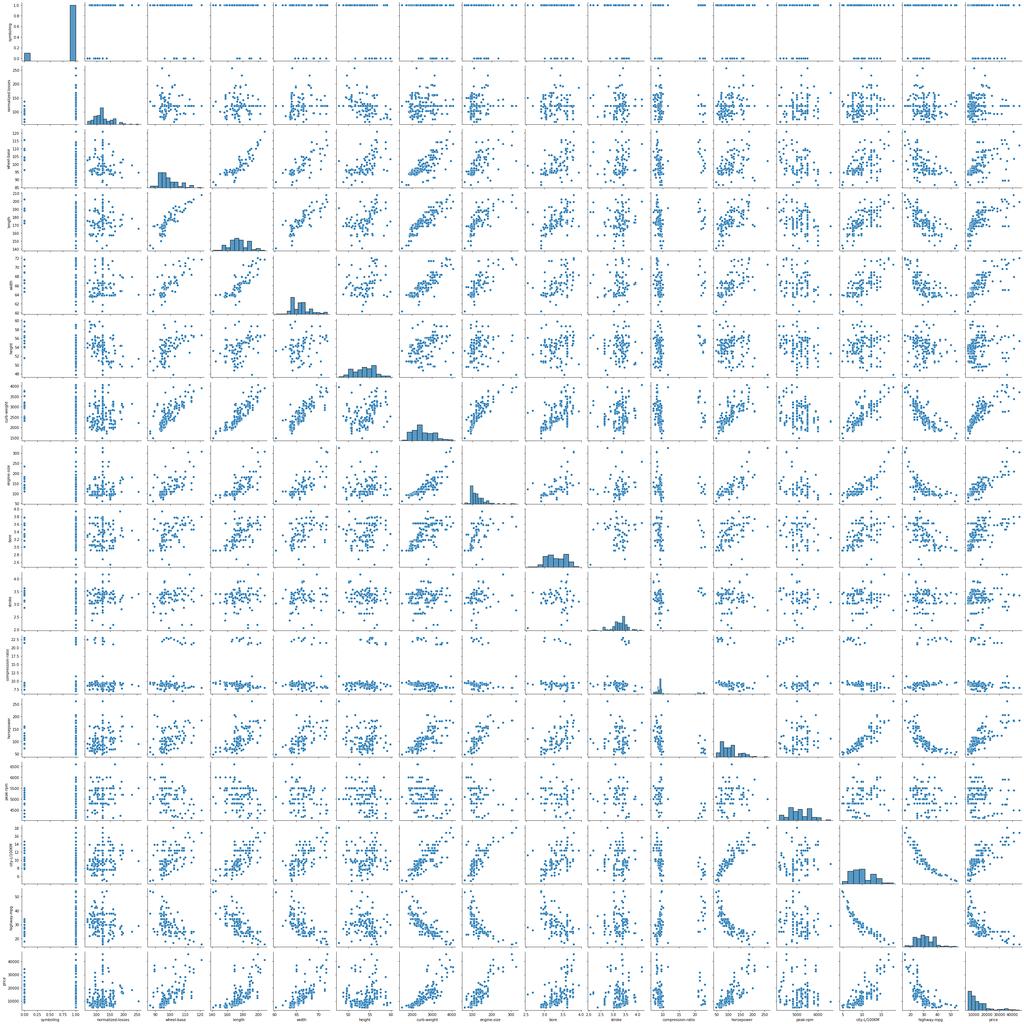

```python
sns.pairplot(automobile)
plt.show()
```

```python
automobile["normalized-losses"].nunique()
```

```
51
```

```python
automobile["normalized-losses"].unique()
```

```
array([122., 164., 158., 192., 188., 121.,  98.,  81., 118., 148., 110.,
       145., 137., 101.,  78., 106.,  85., 107., 104., 113., 150., 129.,
       115.,  93., 142., 161., 153., 125., 128., 103., 168., 108., 194.,
       231., 119., 154.,  74., 186.,  83., 102.,  89.,  87.,  77.,  91.,
       134.,  65., 197.,  90.,  94., 256.,  95.])
```

### Scatter plot

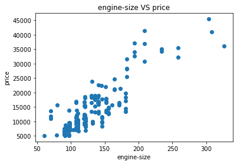

```python
x=automobile['engine-size']
y=automobile['price']
plt.scatter(x,y)
plt.title("engine-size VS price")
plt.xlabel('engine-size')
plt.ylabel('price')
```

```
(0.0, 53562.38057069233)
```

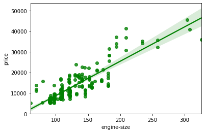

```python
sns.regplot(x="engine-size",y="price",data=automobile,color="green")
plt.ylim(0,)
```

## INFERENCE

#### we see that as the engine size goes up,the price of the car also goes up,indicate that there is a positive linear relationship b/w engine size and price

# Count plot

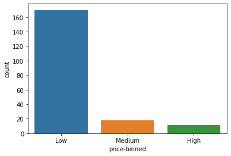

```python
sns.countplot("price-binned",data=automobile)
plt.show()
import warnings
warnings.filterwarnings("ignore")
```

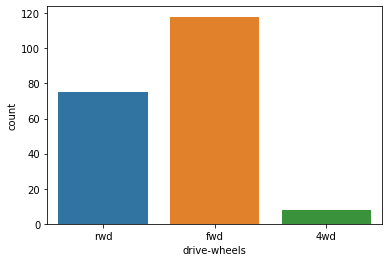

```python
sns.countplot("drive-wheels",data=automobile)
plt.show()
```

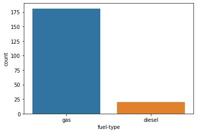

```python
sns.countplot("fuel-type",data=automobile)
plt.show()
```

## INFERENCE

#### No.of fwd cars are between 100-120,there may be 60-80 rwd cars and the least no.of cars(<20) are 4wd

#### Most of the cars(>175) use gas as fuel and the no.of cars using diesel as fuel is less than 25

# Dist plot

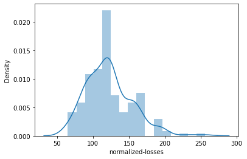

```python
sns.distplot(automobile["normalized-losses"])
plt.show()
```

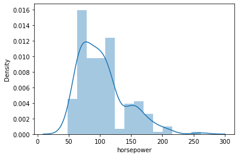

```python
sns.distplot(automobile["horsepower"])
plt.show()
```

## INFERENCE

#### Distribution of "normalized-losses" is skewed

# Cat plot

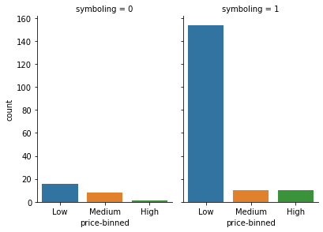

```python
sns.catplot(x="price-binned",col="symboling",data=automobile,kind="count",height=4,aspect=.7)
plt.show()
```

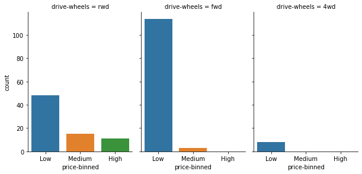

```python
sns.catplot(x="price-binned",col="drive-wheels",data=automobile,kind="count",height=4,aspect=.7)
```

## INFERENCE

#### Most of the cars in risky state, and having least price

#### Most of the cars have forward wheel drive(fwd), also have low price. Secondly the cars have rear wheel drive(rwd)

# Boxplot

```python
import seaborn as sns
%matplotlib inline
import matplotlib.pyplot as plt
```

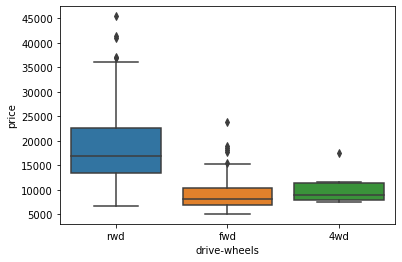

```python
sns.boxplot(x="drive-wheels",y="price",data=automobile)
plt.show()
```

# Bar plot

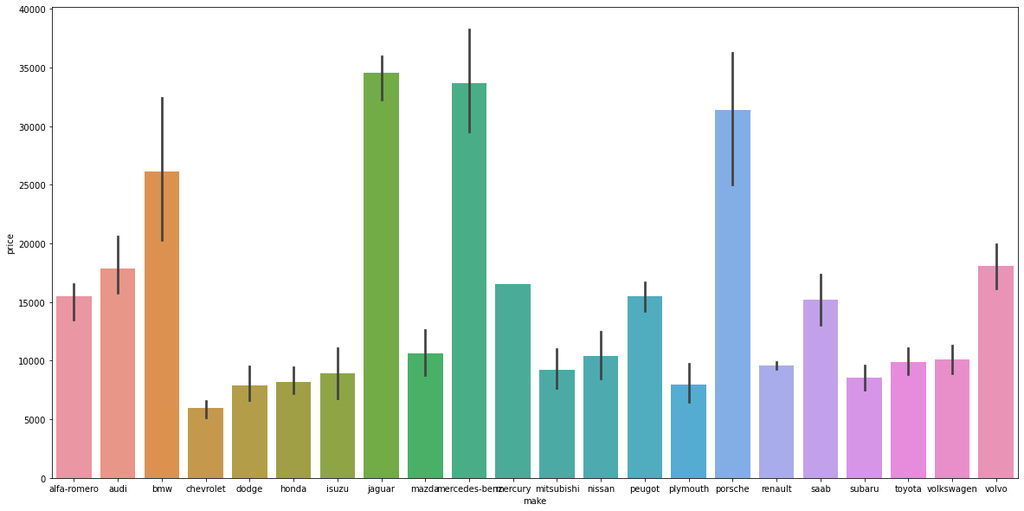

```python
plt.figure(figsize=(20,10))
sns.barplot(x="make",y="price",data=automobile)
plt.show()
```

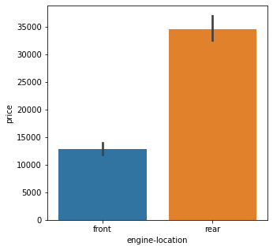

```python
plt.figure(figsize=(5,5))
sns.barplot(x="engine-location",y="price",data=automobile)
plt.show()
```

## INFERENCE

#### Highly priced cars are made by jaguar, secondly mercedes-bense

#### it seems like car having engine at rear are much more costiler than cars whoes engine at front

# Outiler detection

#### Boxplots display “outliers” as individual dots that occur outside the upper and lower extremes. With boxplots, you can easily spot outliers.

```python
data=automobile.drop(["symboling","make","fuel-type","aspiration","num-of-doors","body-style","drive-wheels","engine-location","engine-type","num-of-cylinders","fuel-system","price-binned"],axis=1)
```

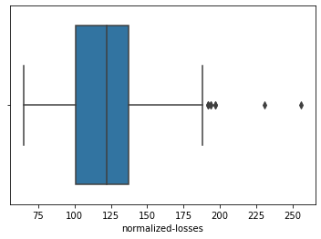

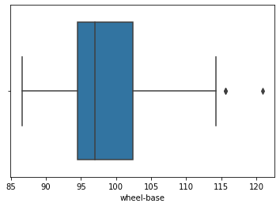

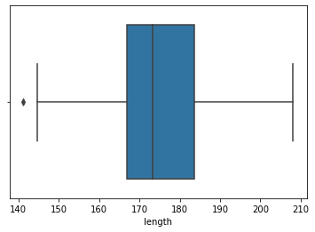

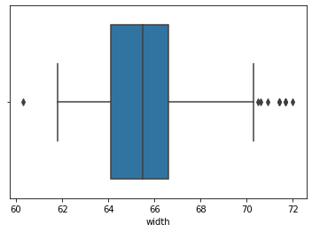

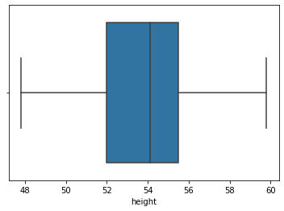

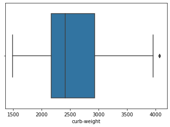

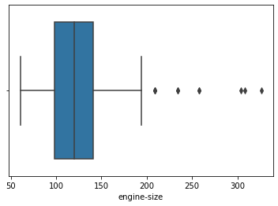

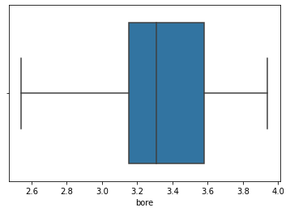

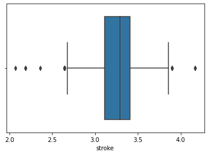

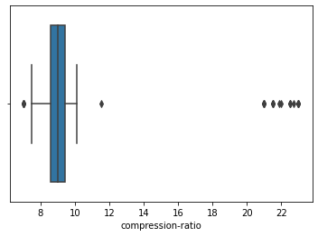

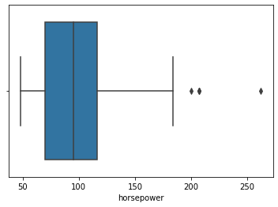

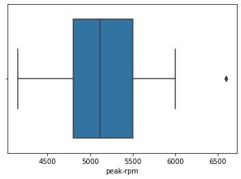

[3 more figures not shown]

```python
for i in data:
    sns.boxplot(x=data[i])
    plt.show()
```

#### Outlier removal of the price column by using the Inter Quartile Range Method

```python
IQR=stats.iqr(data.price, interpolation="midpoint")
IQR
```

```
8725.0
```

```python
Q1=data.price.quantile(0.25)
Q3=data.price.quantile(0.75)
min_limit=Q1-1.5*IQR
max_limit=Q3+1.5*IQR
```

```python
min_limit
```

```
-5312.5
```

```python
max_limit
```

```
29587.5
```

```python
data.loc[data["price"]>max_limit]
```

|  | normalized-losses | wheel-base | length | width | height | curb-weight | engine-size | bore | stroke | compression-ratio | horsepower | peak-rpm | city-L/100KM | highway-mpg | price |
| --- | --- | --- | --- | --- | --- | --- | --- | --- | --- | --- | --- | --- | --- | --- | --- |
| 14 | 122.0 | 103.5 | 189.0 | 66.9 | 55.7 | 3230 | 209 | 3.62 | 3.39 | 8.0 | 182.0 | 5400.0 | 14.687500 | 22 | 30760.0 |
| 15 | 122.0 | 103.5 | 193.8 | 67.9 | 53.7 | 3380 | 209 | 3.62 | 3.39 | 8.0 | 182.0 | 5400.0 | 14.687500 | 22 | 41315.0 |
| 16 | 122.0 | 110.0 | 197.0 | 70.9 | 56.3 | 3505 | 209 | 3.62 | 3.39 | 8.0 | 182.0 | 5400.0 | 15.666667 | 20 | 36880.0 |
| 44 | 145.0 | 113.0 | 199.6 | 69.6 | 52.8 | 4066 | 258 | 3.63 | 4.17 | 8.1 | 176.0 | 4750.0 | 15.666667 | 19 | 32250.0 |
| 45 | 122.0 | 113.0 | 199.6 | 69.6 | 52.8 | 4066 | 258 | 3.63 | 4.17 | 8.1 | 176.0 | 4750.0 | 15.666667 | 19 | 35550.0 |
| 46 | 122.0 | 102.0 | 191.7 | 70.6 | 47.8 | 3950 | 326 | 3.54 | 2.76 | 11.5 | 262.0 | 5000.0 | 18.076923 | 17 | 36000.0 |
| 67 | 93.0 | 115.6 | 202.6 | 71.7 | 56.3 | 3770 | 183 | 3.58 | 3.64 | 21.5 | 123.0 | 4350.0 | 10.681818 | 25 | 31600.0 |
| 68 | 122.0 | 115.6 | 202.6 | 71.7 | 56.5 | 3740 | 234 | 3.46 | 3.10 | 8.3 | 155.0 | 4750.0 | 14.687500 | 18 | 34184.0 |
| 69 | 142.0 | 96.6 | 180.3 | 70.5 | 50.8 | 3685 | 234 | 3.46 | 3.10 | 8.3 | 155.0 | 4750.0 | 14.687500 | 18 | 35056.0 |
| 70 | 122.0 | 120.9 | 208.1 | 71.7 | 56.7 | 3900 | 308 | 3.80 | 3.35 | 8.0 | 184.0 | 4500.0 | 16.785714 | 16 | 40960.0 |
| 71 | 122.0 | 112.0 | 199.2 | 72.0 | 55.4 | 3715 | 304 | 3.80 | 3.35 | 8.0 | 184.0 | 4500.0 | 16.785714 | 16 | 45400.0 |
| 123 | 122.0 | 89.5 | 168.9 | 65.0 | 51.6 | 2756 | 194 | 3.74 | 2.90 | 9.5 | 207.0 | 5900.0 | 13.823529 | 25 | 32528.0 |
| 124 | 122.0 | 89.5 | 168.9 | 65.0 | 51.6 | 2756 | 194 | 3.74 | 2.90 | 9.5 | 207.0 | 5900.0 | 13.823529 | 25 | 34028.0 |
| 125 | 122.0 | 89.5 | 168.9 | 65.0 | 51.6 | 2800 | 194 | 3.74 | 2.90 | 9.5 | 207.0 | 5900.0 | 13.823529 | 25 | 37028.0 |

```python
data.loc[data["price"]>max_limit,"price"]=np.max(data.price)
```

```python
data["price"].head(10)
```

```
0    13495.0
1    16500.0
2    16500.0
3    13950.0
4    17450.0
5    15250.0
6    17710.0
7    18920.0
8    23875.0
9    16430.0
Name: price, dtype: float64
```

```python
automobile["price"]=data["price"]
```

```python
automobile["price"].head(10)
```

```
0    13495.0
1    16500.0
2    16500.0
3    13950.0
4    17450.0
5    15250.0
6    17710.0
7    18920.0
8    23875.0
9    16430.0
Name: price, dtype: float64
```

# Label encoding

#### Using label encoder changing the values of the 10 object columns

```python
from sklearn.preprocessing import LabelEncoder
le = LabelEncoder()
automobile['make'] = le.fit_transform(automobile['make'])
```

```python
automobile['fuel-type'] = le.fit_transform(automobile['fuel-type'])
```

```python
automobile['aspiration'] = le.fit_transform(automobile['aspiration'])
```

```python
automobile['num-of-doors'] = le.fit_transform(automobile['num-of-doors'])
```

```python
automobile['body-style'] = le.fit_transform(automobile['body-style'])
```

```python
automobile['drive-wheels'] = le.fit_transform(automobile['drive-wheels'])
```

```python
automobile['engine-location'] = le.fit_transform(automobile['engine-location'])
```

```python
automobile['engine-type'] = le.fit_transform(automobile['engine-type'])
```

```python
automobile['num-of-cylinders'] = le.fit_transform(automobile['num-of-cylinders'])
```

```python
automobile['fuel-system'] = le.fit_transform(automobile['fuel-system'])
```

```python
automobile.info()
```

```
<class 'pandas.core.frame.DataFrame'>
RangeIndex: 201 entries, 0 to 200
Data columns (total 27 columns):
 #   Column             Non-Null Count  Dtype
---  ------             --------------  -----
 0   symboling          201 non-null    int64
 1   normalized-losses  201 non-null    float64
 2   make               201 non-null    int32
 3   fuel-type          201 non-null    int32
 4   aspiration         201 non-null    int32
 5   num-of-doors       201 non-null    int32
 6   body-style         201 non-null    int32
 7   drive-wheels       201 non-null    int32
 8   engine-location    201 non-null    int32
 9   wheel-base         201 non-null    float64
```

[output cut: 19 more lines]

# Heatmap

#### A heat map can explain the correlation between the variables with the color intensity. It is a great way to plot the target variable over multiple variables and through this get visual clues of the relationship between variables and the target. As we now have to move into building machine learning models to automate our analysis, feeding the model with variables that meaningfully affect our target variable will improve our model’s prediction performance

```python
corr=automobile.corr()
```

[output not shown]

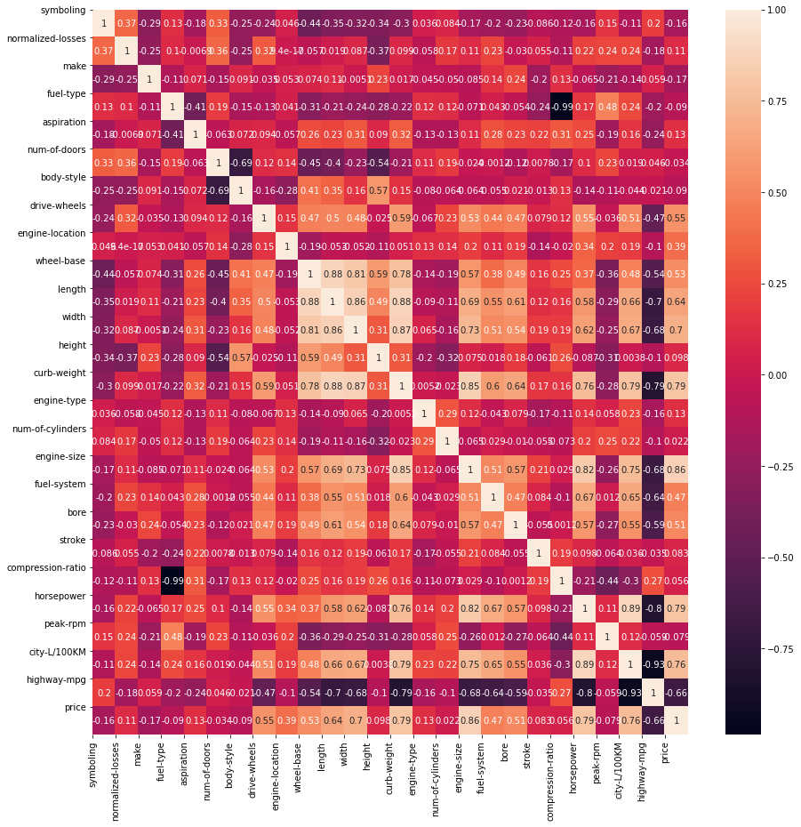

```python
fig,ax=plt.subplots(figsize=(15,15))
colormap=sns.diverging_palette(220,10,as_cmap=True)
sns.heatmap(corr,annot=True)
plt.xticks(range(len(corr.columns)),corr.columns);
plt.yticks(range(len(corr.columns)),corr.columns)
```

# Because our price is continous so this is regression problem

### APPLYING DIFFERENT ALGORITHMS ON TRAINING SET

### from heatmap we take important features

## LINEAR REGRESSION

```python
corr_ =automobile.corr()["price"]*100
corr_
```

```
symboling            -16.349714
normalized-losses     10.935687
make                 -17.148737
fuel-type             -8.972879
aspiration            13.129128
num-of-doors          -3.414560
body-style            -9.017306
drive-wheels          55.335816
engine-location       39.332754
wheel-base            53.065623
length                63.638794
width                 69.608297
height                 9.821240
curb-weight           79.114851
engine-type           12.723166
num-of-cylinders       2.213395
engine-size           86.129105
fuel-system           46.984050
bore                  50.866227
stroke                 8.308275
compression-ratio      5.599010
horsepower            79.133086
peak-rpm              -7.903260
city-L/100KM          75.710028
highway-mpg          -65.901349
price                100.000000
Name: price, dtype: float64
```

```python
corr_[corr_ >60].index
```

```
Index(['length', 'width', 'curb-weight', 'engine-size', 'horsepower',
       'city-L/100KM', 'price'],
      dtype='object')
```

```python
l=[10,11,13,16,21,23]
```

```python
x=automobile.iloc[:,l]
y=automobile['price']
```

```python
from sklearn . model_selection import train_test_split
xtrain,xtest,ytrain,ytest=train_test_split(x,y,test_size=.2,random_state=149)
```

```python
from sklearn.linear_model import LinearRegression
lr=LinearRegression()
from sklearn.metrics import r2_score

lr.fit(xtrain,ytrain)
ypred=lr.predict(xtest)
```

```python
ytrain_pred=lr.predict(xtrain)
print("Training Accuracy :" ,r2_score(ytrain,ytrain_pred))
```

```
Training Accuracy : 0.7749770819699441
```

```python
acc=r2_score(ytest,ypred)
print("Testing Accuracy :" ,acc)
```

```
Testing Accuracy : 0.7788961491005311
```

```python
corr_[corr_ >70]
```

```
curb-weight      79.114851
engine-size      86.129105
horsepower       79.133086
city-L/100KM     75.710028
price           100.000000
Name: price, dtype: float64
```

```python
l1=[13,16,21,23]
```

```python
x1=automobile.iloc[:,l1]
y1=automobile['price']
```

```python
from sklearn . model_selection import train_test_split
x1train,x1test,y1train,y1test=train_test_split(x1,y1,test_size=.2,random_state=149)
```

```python
lr.fit(x1train,y1train)
y1_pred=lr.predict(x1test)
```

```python
y1train_pred=lr.predict(x1train)
print("Training Accuracy :" ,r2_score(y1train,y1train_pred))
```

```
Training Accuracy : 0.7680386448398732
```

```python
acc1=r2_score(y1test,y1_pred)
print("Testing Accuracy :" ,acc1)
```

```
Testing Accuracy : 0.7926630234838306
```

```python
corr_[corr_ >50].index
```

```
Index(['drive-wheels', 'wheel-base', 'length', 'width', 'curb-weight',
       'engine-size', 'bore', 'horsepower', 'city-L/100KM', 'price'],
      dtype='object')
```

```python
l2=[7,9,10,11,13,16,18,21,23]
```

```python
x2=automobile.iloc[:,l2]
y2=automobile['price']
```

```python
from sklearn . model_selection import train_test_split
x2train,x2test,y2train,y2test=train_test_split(x2,y2,test_size=.2,random_state=149)
```

```python
lr.fit(x2train,y2train)
y2pred=lr.predict(x2test)
```

```python
y2train_pred=lr.predict(x2train)
print("Training Accuracy :" ,r2_score(y2train,y1train_pred))
```

```
Training Accuracy : 0.7680386448398732
```

```python
acc1=r2_score(y2test,y2pred)
print("Testing accuracy :",acc1)
```

```
Testing accuracy : 0.78685991314904
```

# feature selection

#### The SelectKBest method selects the features according to the k highest scores. Selecting best features is important process when we prepare a large dataset for training.

```python
from sklearn.feature_selection import SelectKBest
from sklearn.feature_selection import chi2
```

#### splitting dataset into training and testing dataset

```python
X=automobile.drop(["price","price-binned"],axis=1)
Y=automobile["price"]
```

```python
#from sklearn.preprocessing import StandardScaler
#sd = StandardScaler()
#X = sd.fit_transform(X)


# when we perform standard scaling some x-values become negative.featyre selection doesnot allow negative inputs
```

```python
uni=SelectKBest(score_func=chi2,k=10)
fit=uni.fit(X,Y)
```

```python
X.columns[fit.get_support(indices=True)].tolist()
```

```
['normalized-losses',
 'make',
 'length',
 'curb-weight',
 'engine-size',
 'fuel-system',
 'compression-ratio',
 'horsepower',
 'peak-rpm',
 'highway-mpg']
```

```python
L1=[1,2,8,13,16,17,20,21,22,24]
X1=automobile.iloc[:,L1]
Y1=automobile['price']
```

```python
from sklearn . model_selection import train_test_split
X1train,X1test,Y1train,Y1test=train_test_split(X1,Y1,test_size=.2,random_state=149)
```

```python
from sklearn.linear_model import LinearRegression
lr=LinearRegression()
lr.fit(X1train,Y1train)
Y1pred=lr.predict(X1test)
```

```python
Y1_train_pred=lr.predict(X1train)
```

```python
print("Training Accuracy :" ,r2_score(Y1_train_pred,Y1train))
```

```
Training Accuracy : 0.8145607516190662
```

```python
Y1_test_pred=lr.predict(X1test)
```

```python
print("Testing Accuracy :" , r2_score(Y1_test_pred,Y1test))
```

```
Testing Accuracy : 0.8611809077305915
```

```python
# changing   k  value
```

```python
uni=SelectKBest(score_func=chi2,k=15)
fit=uni.fit(X,Y)
```

```python
X.columns[fit.get_support(indices=True)].tolist()
```

```
['normalized-losses',
 'make',
 'aspiration',
 'num-of-doors',
 'wheel-base',
 'length',
 'curb-weight',
 'engine-type',
 'engine-size',
 'fuel-system',
 'compression-ratio',
 'horsepower',
 'peak-rpm',
 'city-L/100KM',
 'highway-mpg']
```

```python
L1=[1,2,4,5,8,9,10,13,16,17,20,21,22,23,24]
X1=automobile.iloc[:,L1]
Y1=automobile['price']
```

```python
from sklearn . model_selection import train_test_split
X1train,X1test,Y1train,Y1test=train_test_split(X1,Y1,test_size=.2,random_state=149)
```

```python
from sklearn.linear_model import LinearRegression
lr=LinearRegression()
lr.fit(X1train,Y1train)
```

```
LinearRegression()
```

```python
Y1_train_pred=lr.predict(X1train)
```

```python
print("Training Accuracy :" ,r2_score(Y1train,Y1_train_pred))
```

```
Training Accuracy : 0.859473528711285
```

```python
Y1_test_pred=lr.predict(X1test)
```

```python
print("Testing Accuracy :" , r2_score(Y1test,Y1_test_pred))
```

```
Testing Accuracy : 0.903692473988363
```

```python
feature=['normalized-losses','make','aspiration','num-of-doors','engine-location','wheel-base','length',
         'curb-weight','engine-size','fuel-system','compression-ratio','horsepower','peak-rpm','city-L/100KM','highway-mpg']
target=["price"]
```

# KNN REGRESSOR

```python
from sklearn.neighbors import KNeighborsRegressor
from sklearn.metrics import mean_squared_error, r2_score
```

```python
L1=[1,2,4,5,8,9,10,13,16,17,20,21,22,23,24]
X1=automobile.iloc[:,L1]
Y1=automobile['price']
```

```python
from sklearn . model_selection import train_test_split
X1train,X1test,Y1train,Y1test=train_test_split(X1,Y1,test_size=.2,random_state=149)
```

```python
knn=KNeighborsRegressor(n_neighbors=10)
knn
knn_reg=knn.fit(X1train,Y1train)
```

```python
# R2 score on training data
X1train_prediction=knn_reg.predict(X1train)
training_R2_score=r2_score(X1train_prediction,Y1train)
```

```python
print("Training Accuracy :", training_R2_score)
```

```
Training Accuracy : 0.616601011261825
```

```python
# R2 score on testing data
X1test_prediction=knn_reg.predict(X1test)
testing_R2_score=r2_score(X1test_prediction,Y1test)
```

```python
print("Testing Accuracy :",testing_R2_score)
```

```
Testing Accuracy : 0.2910944651971692
```

# RANDOM FPREST REGRESSOR

```python
L1=[1,2,4,5,8,9,10,13,16,17,20,21,22,23,24]
X1=automobile.iloc[:,L1]
Y1=automobile['price']
```

```python
from sklearn . model_selection import train_test_split
X1train,X1test,Y1train,Y1test=train_test_split(X1,Y1,test_size=.2,random_state=149)
```

```python
from sklearn.ensemble import RandomForestRegressor
Regressor=RandomForestRegressor(n_estimators=10, random_state=149)
model_reg=Regressor.fit(X1train,Y1train)
```

```python
Y1train_pred_reg=Regressor.predict(X1train)
```

```python
from sklearn.metrics import r2_score
acc1=r2_score(Y1train_pred_reg,Y1train)
```

```python
print("Training Accuracy :", acc1)
```

```
Training Accuracy : 0.9806127162220095
```

```python
Y1_pred_reg=Regressor.predict(X1test)
```

```python
from sklearn.metrics import r2_score
acc=r2_score(Y1_pred_reg,Y1test)
```

```python
print("Testing Accuracy :", acc)
```

```
Testing Accuracy : 0.9586902328814783
```

## EVALUATION OF MODELS

```python
names=["Linear Regression 1(corr>50)","Linear Regression 1(corr>60)","Linear Regression 1(corr>70)","Linear Regression(using feature selection)","KNN Regressor","Random Forest"]
train_accuracy=[0.7680386448398732, 0.7749770819699441,0.7680386448398732, 0.859473528711285,0.616601011261825,0.9806127162220095]
test_accuracy=[0.78685991314904,0.7788961491005311, 0.7926630234838306,0.903692473988363,0.2910944651971692,0.9586902328814783]
d={"Model Used":names,"Train Accuracy":train_accuracy,"Testing Accuracy":test_accuracy}
df=pd.DataFrame(data=d)
df
```

|  | Model Used | Train Accuracy | Testing Accuracy |
| --- | --- | --- | --- |
| 0 | Linear Regression 1(corr>50) | 0.768039 | 0.786860 |
| 1 | Linear Regression 1(corr>60) | 0.774977 | 0.778896 |
| 2 | Linear Regression 1(corr>70) | 0.768039 | 0.792663 |
| 3 | Linear Regression(using feature selection) | 0.859474 | 0.903692 |
| 4 | KNN Regressor | 0.616601 | 0.291094 |
| 5 | Random Forest | 0.980613 | 0.958690 |

# CONCLUSION: We have analysed used car data using machine learning to predict price of automobiles. We have used Linear regression, KNN regressor and Random forest regressor.We trained our models with 15 features. Random Forest model is the best fit to the data, it gives highest accuracy of 95.86%.